# Data vs Decision Science, O-Notation, Lasso, Ridge, Graphical Models

# Table of Contents

## Data Science vs Decision Science

There is often confusion between Data Science and Decision Science. However there is a major difference between these two terms:

**Data Science**

> "*Interdisciplinary field that uses scientific algorithms, methods, techniques and various approaches to extract valuable insight from structured and unstructured data.*"

> Data is the tool for business improvement and development.</center>

**Decision Science**

> "*An application of a complex of quantitative techniques to facilitate the decision-making process.*"

> Data is a tool to make decisions.

A data scientist is often dedicated to one specific product or feature and spends a lot of time gathering accurate data, running statistical analysis and improving it. He has deep knowledge of their product and less of the ecosystem.

A decision scientist normally supports the decision takers in a company, for example how much budget the marketing department should spend on tv advertisement. He is helping to make decisions about budgets and priorities and therefore prepares graphs and tables to support it. Basis is often the outcome of Data Science colleagues.

**Looking at the videogames sales dataset** a decision science use case could for example be to analyse if the sales was increasing or falling the year before and therefore the decision can be taken if a new videogame should be developed or not. A data science approach would rather analyse what were the influences of increasing or falling sales numbers (altough analysing a sales dataset is primarily useful to make a decision anyways.)

## O-Notation

> "*In programming, an algorithm is a process or set of rules to be followed in order to achieve a particular goal. An algorithm is >characterized by its running time (run-time), whether in terms of space or time. As data scientists, we are interested in the >most efficient algorithm so that we can optimize our workflow.*"

The picture below shows how the kind of operations in an algorithm influences the runtime.

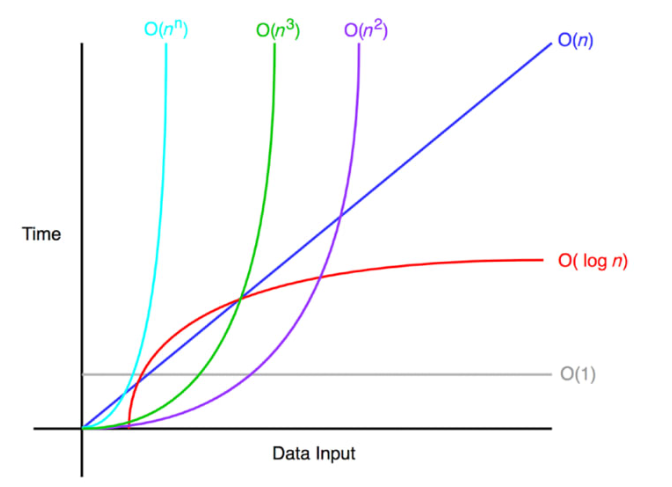

For the videogames dataset, the O-Notation can for example play a role in a regression model for the sales data. Since linear models will always have advantages in computational power, especially generalized linear models are a good approach for regression.

## Generalized Linear Models

A linear relationship is a common way to describe the relationship between input variables $X_1, X_2, ..., X_n$ and an output variable $Y$ and is written as in the following formula, fitted using least squares:

$$ Y = \beta_0 + \beta_1 X_1 + ... + \beta_n X_n + \epsilon $$

Especially in real-world problems, a linear approach is often surprisingly competitive in comparison to a non-linear model. That is why, before moving to a non-linear world, we want to take into account some approaches for extending the linear model framework. In these extensions, the plain least squares fitting is replaced with some alternative fitting procedures. They can have a better prediction accuracy than a model fitted using OLS, especially if the number of predictors is higher than the number of samples, since there will be too much variability in the least squares fit, resulting in overfitting. Furthermore, an alternative linear model can have a better model interpretability due to the possible exclusion of irrelevant variables.

Three of the alternative fitting approaches are the following:

- **Subset Selection**, where a subset of the available predictors is chosen either by *Best Subset Selection* (trying all combinations with any possible amount of predictors) or *Stepwise Selection* (starting with one predictor and stepwise adding new ones, starting with all predictors and stepwise removing the most irrelevant ones, or a combination). Besides statistical approaches to choose the best compromise between the model accuracy and the amount of predictors, cross validation is a more common approach.
- **Shrinkage Models** uses all predictors to fit a model, but uses a technique that shrinks the coefficient estimates towards zero and can therefore significantly reduce their variance. The two best known models are *Ridge Regression* and *Lasso Regression* which will be shown later in the chapter.
- **Dimension Reduction** projects the predictors into an M-Dimensional subspace, where M < as the amount of predictors. The projections aim to explain a big part of the variance in data and are used to fit a model using least squares.

### Ridge Regression

> "*Ridge Regression is very similar to learst squares, except that the coefficients are estimated by minimizing a slightly different quantity.*"

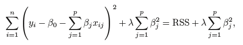

The *Ridge Regression* seeks identically as with least squares (*RSS*) coefficient estimates that fit the data well, by minimizing RSS. An additional term is added, $\lambda\sum_{j=1}^{p}\beta _{j}^{2}$, called the **shrinkage penalty**. The penalty is small when the coefficients $\beta_{1}, ...,\beta_{p}$ are close to zero, and therefore it has the effect of shrinking the estimates of $\beta_{j}$ to zero. The **tuning parameter** $\lambda$ controls the relative impact of the shrinkage penalty compared to the RSS. For selecting a good value for $\lambda$, again cross validation is the best approach.

> "*Ridge regression’s advantage over least squares is rooted in the bias-variance-trade-off. As $\lambda$ increases, the flexibility of the ridge regression fit decreases, leading to decreased variance but increased bias.*"

A good use-case for Ridge Regression is for data where the relationship between predictors and response is close to linear. In this case, it can significantly reduce variance (resulting in slightly higher bias) and perform much better on the test dataset. And also if the number of predictors is higher than the numbers of samples: in this case, least squares may not even have a unique solution, whereas ridge regression still performs well.

### Lasso Regression

Ridge Regression has one big disadvantage, which is that it includes all the predictors in the final model, since the l2 penalty will not set any of them to exactly zero. The *Lasso* is an alternative that overcomes this disadvantage.

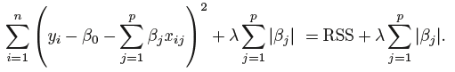

> "*We see that the lasso and ridge regression have similar formulations. The only difference is that the $\beta _{j}^{2}$ term in the ridge regression penalty has been replaced by |$\beta_{j}$| in the lasso penalty.*"

When the tuning parameter $\lambda$ is sufficiently large , this l1 penalty has the effect of forcing some of the coefficient estimates to be exactly equal to zero. Hence, the lasso performs variable selection and therefore the model is a *sparse* model and is easier to interpret compared to the ridge regression model. Depending on the value of lambda, the lasso can produce a model with any number of variables.

### Elastic Net

Elastic Net performs a combination of Ridge and Lasso Models.

### Example with Videogames Dataset

We want to compare linear regression with ridge and lasso regression on the videogames dataset.

#### Prepare dataset

```python
import pandas as pd
import seaborn as sns
import numpy as np
import matplotlib.pyplot as plt
import datetime
from sklearn.linear_model import LinearRegression
import operator
from sklearn.preprocessing import PolynomialFeatures

with open('./vgsales.csv', mode='r') as file:
    df = pd.read_csv(file)

df
```

|  | Rank | Name | Platform | Year | Genre | Publisher | NA_Sales | EU_Sales | JP_Sales | Other_Sales | Global_Sales |
| --- | --- | --- | --- | --- | --- | --- | --- | --- | --- | --- | --- |
| 0 | 1 | Wii Sports | Wii | 2006.0 | Sports | Nintendo | 41.49 | 29.02 | 3.77 | 8.46 | 82.74 |
| 1 | 2 | Super Mario Bros. | NES | 1985.0 | Platform | Nintendo | 29.08 | 3.58 | 6.81 | 0.77 | 40.24 |
| 2 | 3 | Mario Kart Wii | Wii | 2008.0 | Racing | Nintendo | 15.85 | 12.88 | 3.79 | 3.31 | 35.82 |
| 3 | 4 | Wii Sports Resort | Wii | 2009.0 | Sports | Nintendo | 15.75 | 11.01 | 3.28 | 2.96 | 33.00 |
| 4 | 5 | Pokemon Red/Pokemon Blue | GB | 1996.0 | Role-Playing | Nintendo | 11.27 | 8.89 | 10.22 | 1.00 | 31.37 |
| ... | ... | ... | ... | ... | ... | ... | ... | ... | ... | ... | ... |
| 16593 | 16596 | Woody Woodpecker in Crazy Castle 5 | GBA | 2002.0 | Platform | Kemco | 0.01 | 0.00 | 0.00 | 0.00 | 0.01 |
| 16594 | 16597 | Men in Black II: Alien Escape | GC | 2003.0 | Shooter | Infogrames | 0.01 | 0.00 | 0.00 | 0.00 | 0.01 |
| 16595 | 16598 | SCORE International Baja 1000: The Official Game | PS2 | 2008.0 | Racing | Activision | 0.00 | 0.00 | 0.00 | 0.00 | 0.01 |
| 16596 | 16599 | Know How 2 | DS | 2010.0 | Puzzle | 7G//AMES | 0.00 | 0.01 | 0.00 | 0.00 | 0.01 |
| 16597 | 16600 | Spirits & Spells | GBA | 2003.0 | Platform | Wanadoo | 0.01 | 0.00 | 0.00 | 0.00 | 0.01 |

16598 rows × 11 columns

```python
# show NaNs
df.isnull().sum()
```

```
Rank              0
Name              0
Platform          0
Year            271
Genre             0
Publisher        58
NA_Sales          0
EU_Sales          0
JP_Sales          0
Other_Sales       0
Global_Sales      0
dtype: int64
```

```python
# drop NaNs, since there are not so many of them
df = df.dropna()
```

We finally want to predict the Global Sales of one Publisher, based on sales data of all other Pusblishers. Therefore we group the data.

```python
df_gr = df.groupby(['Year','Publisher']).sum()
df_gr = df_gr.drop(['Rank'], axis=1)
df_gr.head()
```

| Year | Publisher | NA_Sales | EU_Sales | JP_Sales | Other_Sales | Global_Sales |
| --- | --- | --- | --- | --- | --- | --- |
| 1980.0 | Activision | 2.82 | 0.18 | 0.0 | 0.03 | 3.02 |
|  | Atari | 7.77 | 0.49 | 0.0 | 0.09 | 8.36 |
| 1981.0 | 20th Century Fox Video Games | 1.27 | 0.07 | 0.0 | 0.01 | 1.35 |
|  | Activision | 7.95 | 0.46 | 0.0 | 0.08 | 8.50 |
|  | Atari | 7.87 | 0.47 | 0.0 | 0.08 | 8.45 |

```python
# change the shape of data frame from multiindex labels to column names
test = df_gr.unstack(level=-1)
test.columns = [' '.join(col).strip() for col in test.columns.values]
test.head()
```

| Year | NA_Sales 10TACLE Studios | NA_Sales 1C Company | NA_Sales 20th Century Fox Video Games | NA_Sales 2D Boy | NA_Sales 3DO | NA_Sales 49Games | NA_Sales 505 Games | NA_Sales 5pb | NA_Sales 7G//AMES | NA_Sales 989 Sports | ... | Global_Sales Zushi Games | Global_Sales bitComposer Games | Global_Sales dramatic create | Global_Sales fonfun | Global_Sales iWin | Global_Sales id Software | Global_Sales imageepoch Inc. | Global_Sales inXile Entertainment | Global_Sales mixi, Inc | Global_Sales responDESIGN |
| --- | --- | --- | --- | --- | --- | --- | --- | --- | --- | --- | --- | --- | --- | --- | --- | --- | --- | --- | --- | --- | --- |
| 1980.0 | NaN | NaN | NaN | NaN | NaN | NaN | NaN | NaN | NaN | NaN | ... | NaN | NaN | NaN | NaN | NaN | NaN | NaN | NaN | NaN | NaN |
| 1981.0 | NaN | NaN | 1.27 | NaN | NaN | NaN | NaN | NaN | NaN | NaN | ... | NaN | NaN | NaN | NaN | NaN | NaN | NaN | NaN | NaN | NaN |
| 1982.0 | NaN | NaN | 0.55 | NaN | NaN | NaN | NaN | NaN | NaN | NaN | ... | NaN | NaN | NaN | NaN | NaN | NaN | NaN | NaN | NaN | NaN |
| 1983.0 | NaN | NaN | NaN | NaN | NaN | NaN | NaN | NaN | NaN | NaN | ... | NaN | NaN | NaN | NaN | NaN | NaN | NaN | NaN | NaN | NaN |
| 1984.0 | NaN | NaN | NaN | NaN | NaN | NaN | NaN | NaN | NaN | NaN | ... | NaN | NaN | NaN | NaN | NaN | NaN | NaN | NaN | NaN | NaN |

5 rows × 2880 columns

Well, there are 2880 columns, so that predictor >> number of samples. Let's see how many Publishers we have...

```python
len(df.Publisher.unique())
```

```
576
```

This is quite a lot, for only 39 years to predict. Let's use the Global_Sales of the 30 Top Publishers for the prediciton.

```python
# get the 30 publishers with the most rows of sales data
from collections import Counter
pub_count = Counter(df.Publisher)
res = pub_count.most_common(30)
```

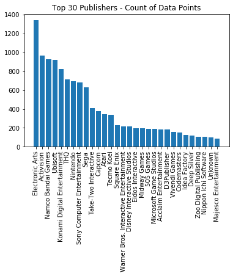

```python
# show as a bar plot
pub = pd.DataFrame([lis[1] for lis in res], [lis[0] for lis in res], columns=['Count'])
plt.bar(pub.index, pub.Count)
plt.xticks(rotation='vertical')
plt.title('Top 30 Publishers - Count of Data Points')
plt.show()
```

```python
# create new table with Global_Sales, named by Publisher, as predictor and Year as Index
gs = pd.DataFrame(df[df.Publisher.isin(pub.index)].groupby(['Year','Publisher']).sum().Global_Sales)
gs = gs.unstack(level=-1)
gs.columns = gs.columns.get_level_values(1)
gs.head()
```

| Publisher Year | 505 Games | Acclaim Entertainment | Activision | Atari | Capcom | Codemasters | D3Publisher | Deep Silver | Disney Interactive Studios | Eidos Interactive | ... | Sony Computer Entertainment | Square Enix | THQ | Take-Two Interactive | Tecmo Koei | Ubisoft | Unknown | Vivendi Games | Warner Bros. Interactive Entertainment | Zoo Digital Publishing |
| --- | --- | --- | --- | --- | --- | --- | --- | --- | --- | --- | --- | --- | --- | --- | --- | --- | --- | --- | --- | --- | --- |
| 1980.0 | NaN | NaN | 3.02 | 8.36 | NaN | NaN | NaN | NaN | NaN | NaN | ... | NaN | NaN | NaN | NaN | NaN | NaN | NaN | NaN | NaN | NaN |
| 1981.0 | NaN | NaN | 8.50 | 8.45 | NaN | NaN | NaN | NaN | NaN | NaN | ... | NaN | NaN | NaN | NaN | NaN | NaN | 0.29 | NaN | NaN | NaN |
| 1982.0 | NaN | NaN | 1.86 | 19.43 | NaN | NaN | NaN | NaN | NaN | NaN | ... | NaN | NaN | NaN | NaN | NaN | NaN | NaN | NaN | NaN | NaN |
| 1983.0 | NaN | NaN | 1.94 | 3.39 | NaN | NaN | NaN | NaN | NaN | NaN | ... | NaN | NaN | NaN | NaN | NaN | NaN | NaN | NaN | NaN | NaN |
| 1984.0 | NaN | NaN | 0.27 | NaN | NaN | NaN | NaN | NaN | NaN | NaN | ... | NaN | NaN | NaN | NaN | NaN | NaN | NaN | NaN | NaN | NaN |

5 rows × 30 columns

We have 29 predictors for one variable to predict with 39 samples. Looks like a great regression sample. We should just impute the NaNs with zero and choose a Publisher to predict which has not many NaNs...

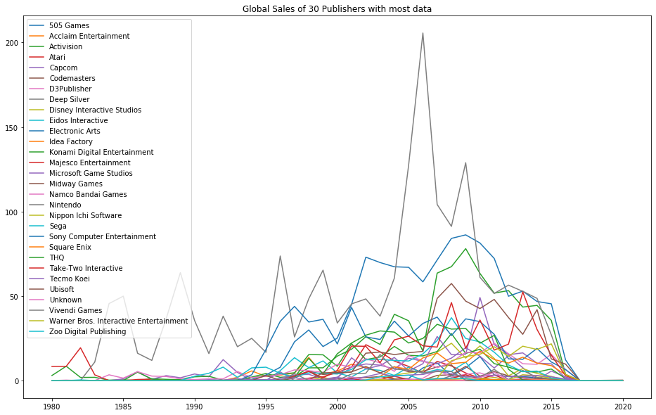

```python
gs.isna().sum()
gs = gs.fillna(0)

# show sales data over time
plt.figure(figsize=[16,10])
plt.plot(gs)
plt.title('Global Sales of 30 Publishers with most data')
plt.legend(gs.columns)
```

We will predict Namco Bandai Games.

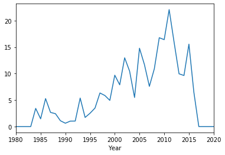

```python
# show variable we want to predict
gs['Namco Bandai Games'].plot()
```

Lets create the train and test data sets.

```python
# train and test set
y = gs['Namco Bandai Games']
X = gs.drop(['Namco Bandai Games'], axis = 1)
```

```python
# train test split with 1/3 as test set
from sklearn.model_selection import train_test_split

X_train, X_test, y_train, y_test = train_test_split(X, y, test_size=0.33, random_state=42)
```

```python
X_train.head()
```

| Publisher Year | 505 Games | Acclaim Entertainment | Activision | Atari | Capcom | Codemasters | D3Publisher | Deep Silver | Disney Interactive Studios | Eidos Interactive | ... | Sony Computer Entertainment | Square Enix | THQ | Take-Two Interactive | Tecmo Koei | Ubisoft | Unknown | Vivendi Games | Warner Bros. Interactive Entertainment | Zoo Digital Publishing |
| --- | --- | --- | --- | --- | --- | --- | --- | --- | --- | --- | --- | --- | --- | --- | --- | --- | --- | --- | --- | --- | --- |
| 1992.0 | 0.00 | 0.00 | 0.00 | 0.00 | 12.40 | 0.00 | 0.00 | 0.00 | 0.00 | 0.00 | ... | 0.00 | 0.00 | 0.00 | 0.00 | 0.29 | 0.00 | 0.00 | 0.0 | 0.00 | 0.0 |
| 1999.0 | 0.00 | 3.83 | 7.57 | 2.30 | 0.88 | 0.61 | 0.00 | 0.00 | 1.94 | 11.64 | ... | 36.24 | 0.00 | 4.01 | 1.68 | 0.63 | 4.61 | 0.00 | 0.4 | 0.00 | 0.0 |
| 1989.0 | 0.00 | 0.00 | 0.47 | 0.15 | 1.67 | 0.00 | 0.00 | 0.00 | 0.00 | 0.00 | ... | 0.00 | 0.00 | 0.00 | 0.00 | 0.00 | 0.00 | 0.00 | 0.0 | 0.00 | 0.0 |
| 2012.0 | 2.34 | 0.00 | 53.25 | 0.05 | 14.68 | 2.81 | 0.29 | 0.64 | 2.84 | 0.00 | ... | 12.85 | 10.37 | 6.70 | 21.58 | 2.43 | 37.31 | 0.32 | 0.0 | 14.33 | 0.0 |
| 1980.0 | 0.00 | 0.00 | 3.02 | 8.36 | 0.00 | 0.00 | 0.00 | 0.00 | 0.00 | 0.00 | ... | 0.00 | 0.00 | 0.00 | 0.00 | 0.00 | 0.00 | 0.00 | 0.0 | 0.00 | 0.0 |

5 rows × 29 columns

Preparation of data is done - now let's try some models.

#### Linear Regression

For comparability, we will try to make a linear regression model to predict the Global Sales of Namco Bandai Games.

```python
#Import Linear Regression model from scikit-learn.
from sklearn.linear_model import LinearRegression
from sklearn.metrics import r2_score, mean_squared_error

#Fit the model
linreg = LinearRegression(normalize=True)
linreg.fit(X_train,y_train)
y_pred = linreg.predict(X_test)

coef = linreg.coef_

# model metrics
print('R2:   ', r2_score(y_test, y_pred))
print('MSE:  ', mean_squared_error(y_test, y_pred))
```

```
R2:    -1821914.037616515
MSE:   27017027.164942358
```

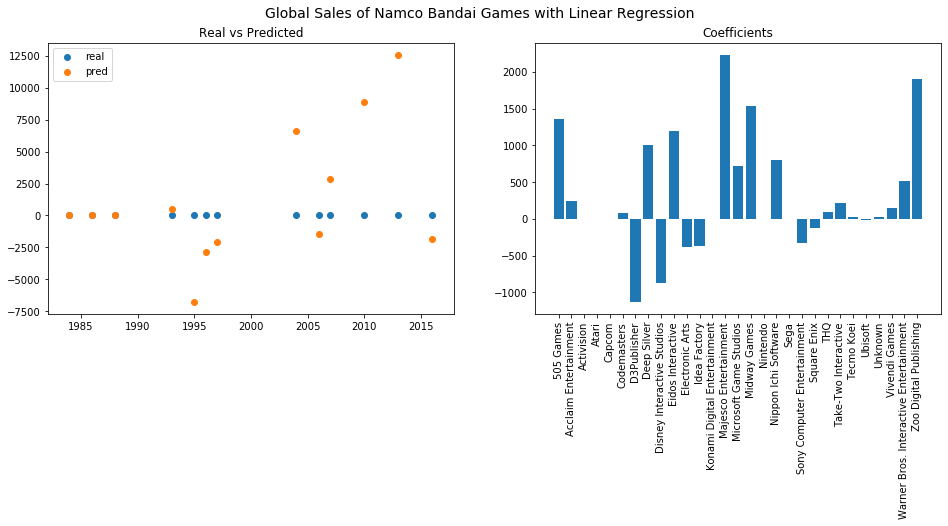

```python
def plt_reg(y_test, y_pred, coef, modelname = 'Regression'):
    plt.figure(figsize=[16, 5])
    plt.suptitle('Global Sales of Namco Bandai Games with {}'.format(modelname), fontsize=14)

    plt.subplot(121)
    plt.scatter(y_test.index, y_test)
    plt.scatter(y_test.index, y_pred)
    plt.title('Real vs Predicted')
    plt.legend(['real', 'pred'])

    plt.subplot(122)
    plt.bar(X_train.columns, coef)
    plt.xticks(rotation='vertical')
    plt.title('Coefficients')

    plt.show()

plt_reg(y_test, y_pred, coef, 'Linear Regression')
```

We see from the R2 and MSE, as well as in the scatter plot comparing the real and the predicted valies, that the predictions don't make any sense. The simple linear regression is not able to make acceptable predictions. As summarized in the theoretical description, the reason is most probably that the amount of predictors is approximately the same as the number of samples, there is too much variance.

#### Ridge Regression

Let's see if ridge regression can do a better job.

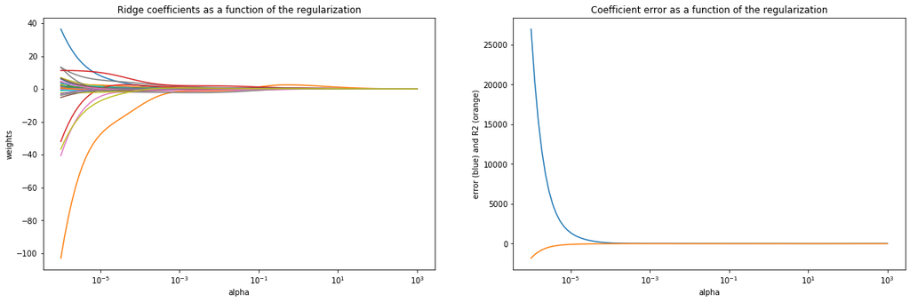

```
Best Alpha:  18.738174228603867
```

```python
# adapted from <Kornel Kielczewski -- <kornel.k@plusnet.pl>
from sklearn.linear_model import Ridge

clf = Ridge(normalize=True)

coefs = []
errors = []
r_squ = []

alphas = np.logspace(-6, 3, 100)

# Train the model with different regularisation strengths
for a in alphas:
    clf.set_params(alpha=a)
    clf.fit(X_train, y_train)
    coefs.append(clf.coef_)
    errors.append(mean_squared_error(y_test, clf.predict(X_test)))
    r_squ.append(r2_score(y_test, clf.predict(X_test)))

# Display results
plt.figure(figsize=(20, 6))

plt.subplot(121)
ax = plt.gca()
ax.plot(alphas, coefs)
ax.set_xscale('log')
plt.xlabel('alpha')
plt.ylabel('weights')
plt.title('Ridge coefficients as a function of the regularization')
plt.axis('tight')

plt.subplot(122)
ax = plt.gca()
ax.plot(alphas, errors)
ax.plot(alphas, r_squ)
ax.set_xscale('log')
plt.xlabel('alpha')
plt.ylabel('error (blue) and R2 (orange)')
plt.title('Coefficient error as a function of the regularization')
plt.axis('tight')

plt.show()

# get best alpha
best_alpha = alphas[errors.index(min(errors))]
print('Best Alpha: ', best_alpha)
```

The best alpha is used to show the prediciton results and the model's coefficients.

```
R2:    0.6747626548257615
MSE:   4.822917648850129
```

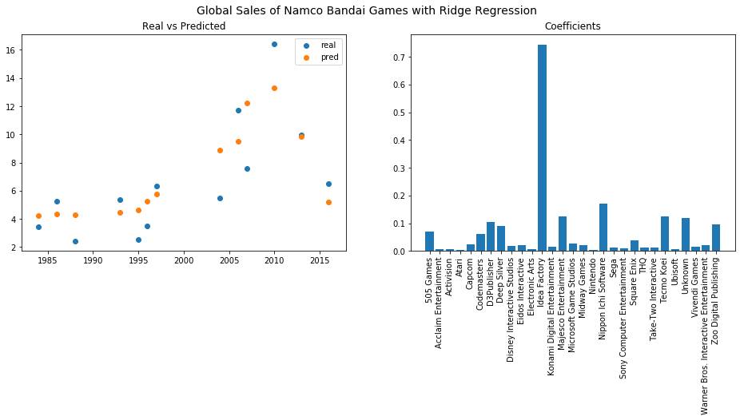

```python
#Fit the Ridge model
ridgereg = Ridge(alpha=best_alpha,normalize=True)
ridgereg.fit(X_train,y_train)
y_pred = ridgereg.predict(X_test)

coef = ridgereg.coef_

# model metrics
print('R2:   ', r2_score(y_test, y_pred))
print('MSE:  ', mean_squared_error(y_test, y_pred))

plt_reg(y_test, y_pred, coef, 'Ridge Regression')
```

The model does a much better job in predicting the global sales of Namco Bandai Games compared to the RSS fit. We can see that Idea Factory is the most important predictor for the modle, many publishers have only a small influence on the predicted values.

#### Lasso Regression

For comparison, we do the same with a lasso regression model.

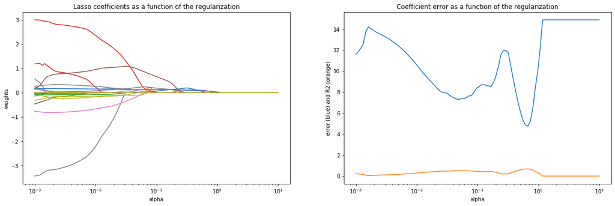

```
Best Alpha:  0.6734150657750828
```

```python
# adapted from <Kornel Kielczewski -- <kornel.k@plusnet.pl>
from sklearn.linear_model import Lasso
clf = Lasso(normalize=True, max_iter=5000)

coefs = []
errors = []
r_squ = []

alphas = np.logspace(-3, 1, 100)

# Train the model with different regularisation strengths
for a in alphas:
    clf.set_params(alpha=a)
    clf.fit(X_train, y_train)
    coefs.append(clf.coef_)
    errors.append(mean_squared_error(y_test, clf.predict(X_test)))
    r_squ.append(r2_score(y_test, clf.predict(X_test)))

# Display results
plt.figure(figsize=(20, 6))

plt.subplot(121)
ax = plt.gca()
ax.plot(alphas, coefs)
ax.set_xscale('log')
plt.xlabel('alpha')
plt.ylabel('weights')
plt.title('Lasso coefficients as a function of the regularization')
plt.axis('tight')

plt.subplot(122)
ax = plt.gca()
ax.plot(alphas, errors)
ax.plot(alphas, r_squ)
ax.set_xscale('log')
plt.xlabel('alpha')
plt.ylabel('error (blue) and R2 (orange)')
plt.title('Coefficient error as a function of the regularization')
plt.axis('tight')

plt.show()

# get best alpha
best_alpha = alphas[errors.index(min(errors))]
print('Best Alpha: ', best_alpha)
```

```
R2:    0.6788742601240231
MSE:   4.761946994488563
```

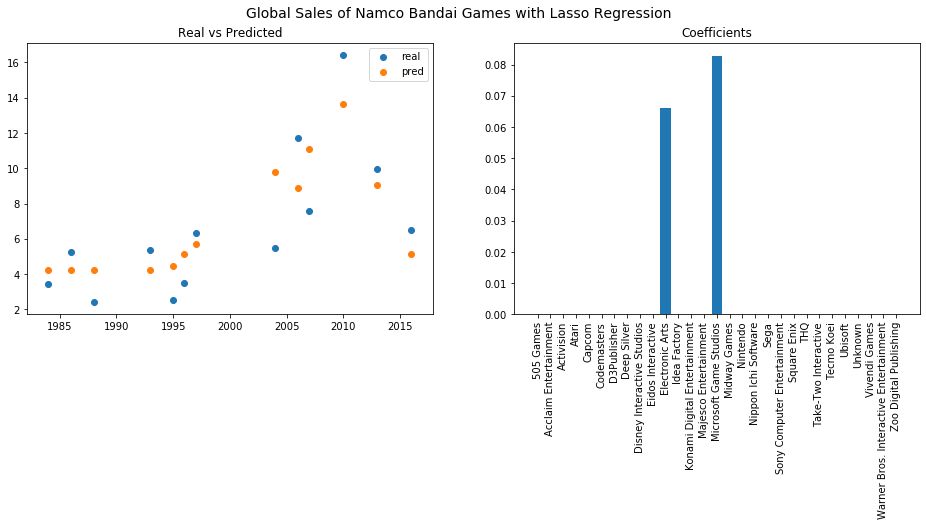

```python
#Fit the Lasso model
lassoreg = Lasso(alpha=best_alpha,normalize=True)
lassoreg.fit(X_train,y_train)
y_pred = lassoreg.predict(X_test)

coef = lassoreg.coef_

# model metrics
print('R2:   ', r2_score(y_test, y_pred))
print('MSE:  ', mean_squared_error(y_test, y_pred))

plt_reg(y_test, y_pred, coef, 'Lasso Regression')
```

```python
coef
```

```
array([0.        , 0.        , 0.        , 0.        , 0.        ,
       0.        , 0.        , 0.        , 0.        , 0.        ,
       0.06605508, 0.        , 0.        , 0.        , 0.08288048,
       0.        , 0.        , 0.        , 0.        , 0.        ,
       0.        , 0.        , 0.        , 0.        , 0.        ,
       0.        , 0.        , 0.        , 0.        ])
```

The lasso regression as well performs well on estimating the values, it is even slightly better than the ridge regression. We also see the major advantage of the lasso: In the model with the best tuning parameter lambda, there are only two coefficients left for the prediction, and all others are set to zero. This makes the model very well interpretable. Microsoft Game Studios is the main predictor, together with Electronic Arts. Idea Factory, which is the most important predictor in the ridge regression, is as well set to zero.

### Discussion of Results

To see how it works, the notebook was also run with all the 576 Publishers instead of using only 30. The Linear Regression got a slightly closer result, but still very far away from the real values. The other models showed following results:

**Ridge results with all 576 Publishers**

```
- R2:    0.628
- MSE:   5.514
```

**Lasso results with all 576 Publishers**

```
- R2:    0.727
- MSE:   4.045
```

The Lasso could improve the fit compared to only using 30 predictors, and again reduced the dimensionality significantly: only 3 predictors where used for this result.

The examples show that ridge and lasso regression can have a huge benefit compared to OLS. The lasso combines the advantage of a linear model (which in terms of computation power always is the one to prefer compared to any other more complex model) with the capability of creating an interpretable model with a large number of predictors.

## Graph Based Algorithmns

For some tasks, we might face some problems if we try to represent data in rows and columns, such with Pandas or any relational database. We might need to consider relationships between entities, instead of seeing them independent. Therefore, a representation of data using nodes and edges is the better way to represent data.

The videogames sales dataset does not offer a way to represent the data as graph. However, some use cases are listed here:

- cities are nodes and highways are edges
- humans are nodes and relationships between them are edges (e.g. social network)
- in a molecule, atoms are nodes and chemical bonds are edges
- web pages are nodes and hyperlinks are edges
- a neural network is kind of a graph: the nodes are the places where computions happen and the edges are the paths that forward the signals through the mathematical operations
- diseases that share tiologies and symptoms or medications that share ingredients can be represented as a graph

The figures below show two examples of graph plots. The first one could for example be a social network with relationships between the humans. The second figure shows a hierarchical graph. This could for example be used to describe an electronic device or any item, with the item itself on the inside and its single components in more and more detailed level on the outside. So, for example the inner node could be "house", on of the middle ones "kitchen", one of the outer ones a "fork".

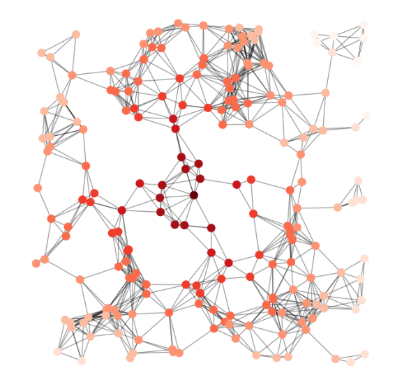

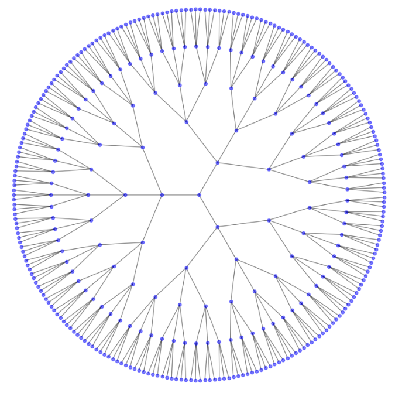

### Data Scientists, The 5 Graph Algorithms that you should know

The *towardsdatascience* article *Data Scientists, The 5 Graph Algorithms that you should know* offers an overview of algorithms:

1) **Connected Components**: can find single islands/cluster in connected data. Fe exaple with data about roads connecting cities in the world, the algorithm could find continents. We use an example on cities around the world to show it. The end result shows the connected components found by the algorithm.

```python
# networkx package helps with graphical models
import networkx as nx
# create a list of edges along with distances between the two nodes
edgelist = [['Mannheim', 'Frankfurt', 85], ['Mannheim', 'Karlsruhe', 80],
            ['Erfurt', 'Wurzburg', 186], ['Munchen', 'Numberg', 167],
            ['Munchen', 'Augsburg', 84], ['Munchen', 'Kassel', 502],
            ['Numberg', 'Stuttgart', 183], ['Numberg', 'Wurzburg', 103],
            ['Numberg', 'Munchen', 167], ['Stuttgart', 'Numberg', 183],
            ['Augsburg', 'Munchen', 84], ['Augsburg', 'Karlsruhe', 250],
            ['Kassel', 'Munchen', 502], ['Kassel', 'Frankfurt', 173],
            ['Frankfurt', 'Mannheim', 85], ['Frankfurt', 'Wurzburg', 217],
            ['Frankfurt', 'Kassel', 173], ['Wurzburg', 'Numberg', 103],
            ['Wurzburg', 'Erfurt', 186], ['Wurzburg', 'Frankfurt', 217],
            ['Karlsruhe', 'Mannheim', 80], ['Karlsruhe', 'Augsburg', 250],
            ["Mumbai", "Delhi",400],["Delhi", "Kolkata",500],
            ["Kolkata", "Bangalore",600],["TX", "NY",1200],["ALB", "NY",800]]
```

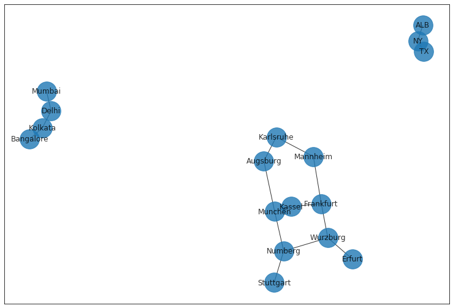

```python
# create a graph instance and add the edges using networkx
g = nx.Graph()
for edge in edgelist:
    g.add_edge(edge[0],edge[1], weight = edge[2])

# show the graph
plt.figure(figsize = [13,9])
nx.draw_networkx(g, node_size = 1000, alpha=0.8)
```

```python
# find out distinct continents: using the connected components algorithm
# print the nodes within one continent
for i, x in enumerate(nx.connected_components(g)):
    print("cc"+str(i)+":",x)
```

```
cc0: {'Karlsruhe', 'Erfurt', 'Mannheim', 'Numberg', 'Wurzburg', 'Munchen', 'Augsburg', 'Frankfurt', 'Stuttgart', 'Kassel'}
cc1: {'Kolkata', 'Delhi', 'Bangalore', 'Mumbai'}
cc2: {'TX', 'ALB', 'NY'}
```

2) **Shortest Path**: Finds the shortest path between two nodes, considering the edge weights (distances in case of connected cities by streets). The example below shows the shortest path between Stuttgart and Mannheim, and the distance of the path.

```python
print(nx.shortest_path(g, 'Stuttgart','Mannheim',weight='weight'))
print(nx.shortest_path_length(g, 'Stuttgart','Mannheim',weight='weight'))
```

```
['Stuttgart', 'Numberg', 'Wurzburg', 'Frankfurt', 'Mannheim']
588
```

Besides geographical data, for example social networks can show friend suggestions based on via how many nodes (other people) two people are connected.

3) **Minimum Spanning Tree**: This algorithm aims to connect all nodes using the minimum amount of distance inbetween. An application for this would be to design a telecommunicaiton network - and someone wants to find out how to connect the components using the minimum amount of cables. Below, the minimum spanning tree of the example with cities is shown:

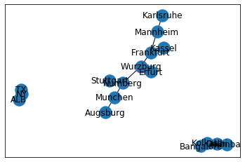

```python
nx.draw_networkx(nx.minimum_spanning_tree(g))
```

4) **Pagerank** ist the page sorting algorithm that powered google for a long time. Scores are assigned to pages, based on the number and quality of incoming and outgoing links, it can for example also be used to find most infuental papers using the citations as a measure.

5) **Centrality Measures**: Centraliy measures can bes used as a feature in any machine learning model. Two examples of centrality measures are the following:

> *Betweenness Centrality* - quantifies how many times a particular node comes in the shortest chosen path between two other nodes.

> *Degree Centrality* - the number of connections for a node.

**Besides these five algorithms**, the representation of data as a graph can be used for any optimization in videogames or to predict weather conditions, using different states as nodes and a probability to get to another node as edges. An example will be shown in *Reinforcement Learning* in Part V.

# *Sources:*

*ISL - Chapter 6: Linear Model Selection and Regularization*

*https://www.kdnuggets.com/2019/05/data-science-vs-decision-science.html*

*https://towardsdatascience.com/data-science-vs-decision-science-8f8d53ce25da*

*https://towardsdatascience.com/a-data-scientists-guide-to-data-structures-algorithms-1176395015a0*

*https://dev.to/b0nbon1/understanding-big-o-notation-with-javascript-25mc*

*https://www.analyticsvidhya.com/blog/2016/01/ridge-lasso-regression-python-complete-tutorial/*

*https://scikit-learn.org/stable/auto_examples/linear_model/plot_ridge_coeffs.html#sphx-glr-auto-examples-linear-model-plot-ridge-coeffs-py*

https://towardsdatascience.com/data-scientists-the-five-graph-algorithms-that-you-should-know-30f454fa5513

https://pathmind.com/wiki/graph-analysis

https://networkx.github.io/documentation/stable/reference/drawing.html